# 2023-01-17-neuro-The Spongy Brain slides

[figure not shown]

## About me

- **Doren**
  - computer engineering @Bilkent-Turkey
  - psychology & neuroscience @Pavia-Italy
- **Relevant-interests**
  - **FAIR** social/medical algorithms
  - the implications of **neuropsychiatry** in everyday life
  - open tools for understanding the human
- **Others**
  - web-dev
  - data-science
  - geo-tools

> WARNING  
> The content is based on sparse readings of the literature.  
> It is by no means an overall introduction to neuroscience.

> INFO  
> The topics might be **overwhelming**, so feel free to jump in at anytime!

## Introduction

*questions, fields, nobel-prizes*

- How is it to be?
  - philosophy
  - cognitive, social, developmental
  - theoretical, computational
- When/where is something broken?
  - medical, imaging, electrophysiology
  - demographics, tests, MRI, EEG, genetics
- How to fix it?
  - therapy, pharmacology, neurotech
- Where can tech help?
  - kind of everywhere...

[figure not shown]

### Mapping the fields

- The dimensions of neuroscience
  - temporal
  - spatial
  - biological depth
- How to handle complexity?
  - pick a field, run with it
  - can knowledge can translate

[figure not shown]

#### Nobel Prizes (src: list at Washington Uni)

| Relevance | Year | People | Nobel Prize Topic |
| --- | --- | --- | --- |
| Systems | 1906 | Golgi, Cajal | Structure of the Nervous System |
|  | 1932 | Adrian, Sherrington | Neurons sending messages, chemical transmission |
|  | 1936 | Dale, Loewi | Chemical transmission of impulses |
|  | 1944 | Erlanger, Gasser | Functions of single nerve fibers |
|  | 1963 | Eccles, Hodgkin, Huxley | Ionic mechanisms of nerve cells membranes |
|  | 1970 | Axelrod, Katz, von Euler | Transmitters and nerve terminals |
|  | 1977 | Guillemin, Schally | Production of peptides in the brain |
|  | 1981 | Hubel & Wiesel, Sperry | Information processing - Visual system, Right-left |
|  | 1982 | Samuelsson, Vane, Bergstrom | Prostaglandins |
|  | 1986 | Cohen, Levi-Montalcini | Nerve Growth Factor |
|  | 1991 | Neher, Sakmann | Function of single ion channels in cells |
|  | 1994 | Gilam, Rodbell | G-protein coupled receptors and their role in signal transduction |
|  | 2000 | Carlsson, Greengard, Kandel | Signal transduction in nervous system/learning |
|  | 2003 | MacKinnon | Structural and mechanistic studies of ion channels |
|  | 2008 | Shimomura, Chalfie, Tsien | Green fluorescent protein (GFP) |
|  | 2013 | Rothman, Schekman, Sudhof | Machinery regulating vesicle traffic, transport system |
|  | 2014 | OKeefe, Moser, Moser | Cells that consistute a positioning system in the brain |
|  | 2017 | Hall, Rosbash, Young | Molecular mechanisms controlling circadian rhythms |

#### Nobel Prizes (src: list at Washington Uni)

| Relevance | Year | People | Nobel Prize Topic |
| --- | --- | --- | --- |
| Anatomy | 1911 | Allvar | Optics |
|  | 1914 | Barany | Vestibular |
|  | 1949 | Hess | Hypothalamus function |
|  | 1961 | Von Bekesy | Cochlea function |
|  | 1967 | Granit, Hartline, Wald | Vision processes |
|  | 2004 | Buck, Axel | Odorant receptors and olfactory system |
|  | 2021 | Julius, Patapoutian | Receptors for temperature and touch |
| Pathology | 1927 | Wagner-Jauregg | Malaria for fixing Dementia |
|  | 1949 | Egas Moniz | Leucotomy for psychoses |
|  | 1976 | Blumberg, Gajdusek | Origin and dissemination of infectious disease |
|  | 1997 | Prusiner | prions: a new biological principle of infection |
| Tools | 1957 | Bovet | Synthetic substances that inhibit action of body substances |
|  | 1979 | Cormack, Houslfield | Computer assisted tomography |
|  | 2003 | Lauterbur, Mansfield | Discoveries concerning magnetic resonance imaging |
| Ethology | 1973 | Lorenz, Tinbergen, von Frisch | Ethology, the study of animal behavior |

## The open resources

[figure not shown]

## Neuroimaging

Can be useful for cognitive studies, stroke, oncology, or geriatrics.

You can use open datasets for studying diseases like AD, Autism, or Schizophrenia. The base idea of neuroimaging is that:

- brain consumes oxygen ~ brain activity
- oxygen usage ~ magnetic resonance

Most analytical tools are built in MATLAB/C++ (`afni`, `fsl`). Lately added some python wrappers (`nilearn`, `nipype`).

[figure not shown]

**Fig.** Different types of MRI.

[figure not shown]

**Fig.** fMRI used for finding relevant nodes.

#### How to: Neuroimaging (src: nilearn documentation)

```
total 196
-rw-rw-r-- 1 delta delta   4184 gen 18 11:16 collection_metadata.json
-rw-rw-r-- 1 delta delta   1802 gen 19 17:33 image_10426_metadata.json
-rw-rw-r-- 1 delta delta 186649 gen 18 11:16 image_10426.nii.gz
```

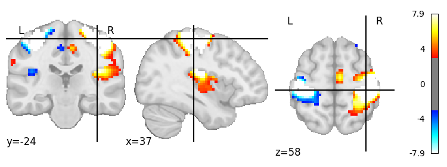

```python
# 1. read MRI
from nilearn import datasets, plotting
motor_images = datasets.fetch_neurovault_motor_task()  # downloads data
# check what was downloaded
!ls -l ~/nilearn_data/neurovault/*/
# significance related image
tmap_filename = motor_images.images[0]
# 2. visualize MRI
plotting.plot_stat_map(tmap_filename, threshold=3)
print()
```

#### Several layers of brain images (src: Neural Data Science)

[figure not shown]

#### Getting started

- [Ni-Edu](https://lukas-snoek.com/NI-edu/index.html)
- [DartBrains](https://dartbrains.org/content/intro.html)
- [Andy's Brain Book: AFNI](https://andysbrainbook.readthedocs.io/en/latest/AFNI/AFNI_Overview.html) - a bit old, but good explanations.

#### Some Tools

- AFNI - step by step analysis - very good tool.
- FSL - software analysis toolbox - more combinations.
- [nilearn](https://nilearn.github.io/) - python pipeline of analysis, as shown above.

## Electrophysiology

Can be useful for cognition, brain computer interfaces (**BCI**), epilepsy, or sleep studies.

There are open datasets for applying tools for recognizing brain waves that might be relevant to the clinical or cognitive studies. This can be helpful for prosthetics and cognitive trainings.

The main analytical tools are `eeglab` (MATLAB) and `mne` (python).

[figure not shown]

**Fig.** Open-BCI waves.

#### How to: Electrophysiology (src: MNE documentation)

```
Opening raw data file /home/delta/mne_data/MNE-sample-data/MEG/sample/sample_audvis_filt-0-40_raw.fif...
    Read a total of 4 projection items:
        PCA-v1 (1 x 102)  idle
        PCA-v2 (1 x 102)  idle
        PCA-v3 (1 x 102)  idle
        Average EEG reference (1 x 60)  idle
    Range : 6450 ... 48149 =     42.956 ...   320.665 secs
Ready.
Using matplotlib as 2D backend.
```

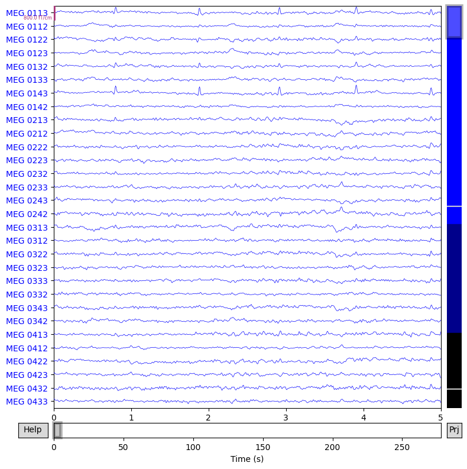

```python
import numpy as np
import mne

# load sample data
sample_data_folder = mne.datasets.sample.data_path()  # WARNING: ~1.65GB
sample_data_raw_file = (sample_data_folder / 'MEG' / 'sample' /
                        'sample_audvis_filt-0-40_raw.fif')
raw = mne.io.read_raw_fif(sample_data_raw_file)

raw.plot(duration=5, n_channels=30)
print()
```

#### Putting it in perspective

```
Projections have already been applied. Setting proj attribute to True.
Removing projector <Projection | PCA-v1, active : True, n_channels : 102>
Removing projector <Projection | PCA-v2, active : True, n_channels : 102>
Removing projector <Projection | PCA-v3, active : True, n_channels : 102>
```

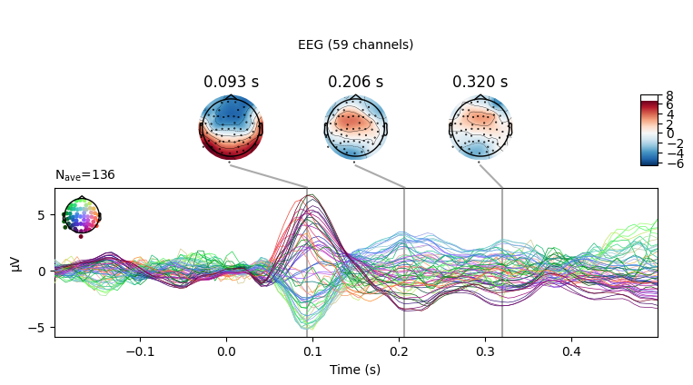

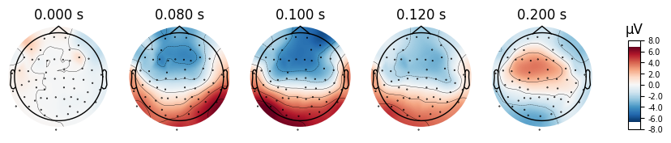

```python
aud_evoked.plot_joint(picks='eeg')
aud_evoked.plot_topomap(times=[0., 0.08, 0.1, 0.12, 0.2], ch_type='eeg')
print()
```

#### EEG waves for Neuropsychiatry (src: Kaggle notebook on EEG)

[figure not shown]

#### Getting started

- [UnivBern - EEG data processing](https://neuro.inf.unibe.ch/AlgorithmsNeuroscience/Tutorial_files/Introduction.html)
- [MNE documentation](https://mne.tools/dev/index.html)
- [Neural Data Science book](https://neuraldatascience.io/intro.html) - a good introduction

#### Some Tools

- [MNE](https://mne.tools/dev/index.html) - python tool for electrophysiology processing.
- [EEGLab](https://sccn.ucsd.edu/eeglab/index.php) - MATLAB tool for processing eeg.

## Data Science/ ML

Can be useful for multimodal data analysis, creating diagnostic/prognostic models for subjects.

The open datasets for complex cases like neurodegeneration or psychiatric diseases allow for building models that can target also single cases, and can provide baseline analysis.

The analytical tools can be statistical models based on `R`, `python`, or `MATLAB`.

[figure not shown]

**Fig.** Impairment level - disorder.  
FTLD, DLB, AD, VaD, MCI, Healthy

#### How to: Datascience for tabular medical data

```
import pandas as pd
from sklearn.model_selection import train_test_split
from sklearn.scoring import f1_score # TODO: check which one is best
from lightgbm import LGBMClassifier

# get data
df = pd.read_csv('data/ADNI.csv')
X_train, X_test, y_train, y_test = train_test_split(
    df.drop('DX', axis=1), df['DX'], test_size=1/3, random_state=0
)
```

```
# create classifier
classifier = LGBMClassifier()
classifier.fit(X_train, y_train)
print(f1_score(X_test, y_test))
```

[figure not shown]

## Fun Esoteric Topics !!!

- Neurotech: body control through brain waves!
- Neurogenetics: comparing brains with evolution-related projects.
- Neuropsychology: body dysmorphia disorders.
- Neuropharmacology: developing drugs through open-science.

## OpenLabs: Possible Contribution

- BCI: test tools related to BCI in the lab (muse/OpenBCI headset).
- Testify: translate neuropsychological tests to ALB, help with standardization.
  - relevant for neurodegenerative diseases - [link to NACC study (extensive testing)](https://naccdata.org/data-collection/forms-documentation/uds-3)
  - relevant for psychiatric diseases - [link to cambridge testing tool (open source)](https://camcops.readthedocs.io/en/latest/tasks/_tasks_by_category.html)
- 3D-Brain: collaborate with *fab-lab*
  - OpenLabs-Tr creates a base structure
  - fab-lab fills the gaps through spongy material
  - **Voila!** You have THE SPONGY BRAIN!!!
- Hackathon: a hackathon for neuroscience in AL, including topics mentioned today.
  - [neurohack-academy](https://github.com/neurohackademy) (great source!)
  - [brainhack](https://brainhack.org/) (possible partner)
  - [neural-hack](https://www.neuralhacks.org/)
- Open-source tools: translate tools to AL, improve existing MRI/EEG/Data-science tools.

### Getting started: Movies

- **Rain Man**: Autism and Savants.
- **Inception**: Creativity and boundaries.
- **Inside out**: The emotions of a child.
- **The Father**: Alzheimer's, identity and more.
- **The Matrix**: Okay, yes, I know what you thinking; but yes.
- **Awakenings**: Encephalitis, Williams and De Niro.
- **A beautiful mind**: On the dieting mind and psychosis.
- As good as it gets: Jack Nicholson at his best, shows OCD in a playful manner.
- Silver Linings Playbook: Mental health disorders, and them facing the world.
- One flew over the cucko's nest: Jack Nicholson again, very good.
- The perks of being a wallflower: Childhood trauma impact on teenagehood, lovely.
- Eternal sunshine of the spotless mind: Memories and pain, Jim Carrey.

### *As good as it gets*

https://www.youtube.com/watch?v=nac6g5Fmi54&ab_channel=%23Carluspro

## References

- Research
  - Robin: https://www.nature.com/articles/s42003-022-04213-y
  - Prognosis: https://ieeexplore.ieee.org/ielaam/6221020/8984617/8765241-aam.pdf
  - ...
- Open-*
  - OpenNeuro
  - MNE-Python
  - EEGLab
  - Open-Targets